# landcover_PCA

Kimberly Ledger

3/3/2022

this code will plot PCA’s using landcover proportion at multiple buffer scales around potential tick collection sites in Alachua County, Florida

load libraries

```r
library(tidyverse)
library(ggplot2)
library(ggbiplot)
```

read in the data

```r
lc <- read.csv("AlCo_landcover_allscales.csv")
head(lc)
```

```
##                                                Site sampled Site_ID Field_Type
## 1            Hatchet Creek Wildlife Management Area       Y      HC    Natural
## 2    Paynes Prairie Preserve State Park (Northside)       N    <NA>    Natural
## 3    Paynes Prairie Preserve State Park (Southside)       Y      PP    Natural
## 4                               Sweetwater Preserve       Y      SW    Natural
## 5 San Felasco Preserve State Park (N of Millhopper)       Y      SF    Natural
## 6 San Felasco Preserve State Park (S of Millhopper)       N    <NA>    Natural
##   p100m_1    p100m_2   p100m_3     p100m_4 p100m_5 p100m_6    p100m_7 p250m_1
## 1       0 0.00000000 0.4358974 0.000000000       0       0 0.56410256       0
## 2       0 0.01929261 0.9453376 0.000000000       0       0 0.03536977       0
## 3       0 0.00000000 0.9873016 0.000000000       0       0 0.01269841       0
## 4       0 0.00000000 0.9935691 0.006430868       0       0 0.00000000       0
## 5       0 0.11858974 0.8814103 0.000000000       0       0 0.00000000       0
## 6       0 0.08306709 0.9169329 0.000000000       0       0 0.00000000       0
##      p250m_2   p250m_3   p250m_4    p250m_5    p250m_6    p250m_7 p500m_1
```

[output cut: 69 more lines]

this is the landcover classification

- 1 = Agriculture
- 2 = Developed
- 3 = Forest
- 4 = Manicured
- 5 = Residential
- 6 = Water
- 7 = Wetland

sampling site selection was based on PC1 using land cover proportions using a 1km buffer around all potential sites

filter data to only include land cover at 1km

```r
lc_1km <- lc[,c(26:32)]
head(lc_1km)
```

```
##       p1km_1     p1km_2    p1km_3     p1km_4      p1km_5      p1km_6     p1km_7
## 1 0.00000000 0.01796693 0.4451594 0.00000000 0.000000000 0.005797840 0.53107579
## 2 0.03828757 0.02930496 0.4200803 0.00000000 0.053704530 0.029432376 0.42919029
## 3 0.00000000 0.02331433 0.6002166 0.00000000 0.007038889 0.000000000 0.36943020
## 4 0.00000000 0.11363854 0.5022460 0.11532702 0.173022396 0.006976966 0.08878907
## 5 0.00000000 0.05848437 0.8703851 0.02054598 0.009811104 0.001529003 0.03924442
## 6 0.00006370 0.06133894 0.8747092 0.02055253 0.010802027 0.001178982 0.03135455
```

```r
lc_1km_log <- log1p(lc_1km)
z_lc <- lc_1km_log
```

run a PCA using the function princomp from the stats package

```r
lc_pca <- princomp(z_lc, cor=F)
#cor=F, because we are using the covariance matrix instead of the correlation matrix

summary(lc_pca)
```

```
## Importance of components:
##                           Comp.1    Comp.2     Comp.3     Comp.4      Comp.5
## Standard deviation     0.2456438 0.1177833 0.08908479 0.06842202 0.022253109
## Proportion of Variance 0.6892758 0.1584706 0.09065433 0.05347775 0.005656696
## Cumulative Proportion  0.6892758 0.8477464 0.93840072 0.99187847 0.997535168
##                             Comp.6       Comp.7
## Standard deviation     0.011723804 0.0088504129
## Proportion of Variance 0.001570068 0.0008947639
## Cumulative Proportion  0.999105236 1.0000000000
```

```r
#get factor loadings for each PC
loadings(lc_pca)
```

```
##
## Loadings:
##        Comp.1 Comp.2 Comp.3 Comp.4 Comp.5 Comp.6 Comp.7
## p1km_1                0.427  0.795  0.180  0.379
## p1km_2 -0.515  0.641        -0.259  0.251  0.439
## p1km_3  0.676         0.273 -0.475  0.230  0.434
## p1km_4                             -0.888  0.442  0.119
## p1km_5 -0.481 -0.762        -0.157  0.172  0.356
## p1km_6                                           -0.991
## p1km_7  0.199        -0.856  0.223  0.160  0.382
##
##                Comp.1 Comp.2 Comp.3 Comp.4 Comp.5 Comp.6 Comp.7
## SS loadings     1.000  1.000  1.000  1.000  1.000  1.000  1.000
## Proportion Var  0.143  0.143  0.143  0.143  0.143  0.143  0.143
## Cumulative Var  0.143  0.286  0.429  0.571  0.714  0.857  1.000
```

```r
# get factor scores for each site
lc_pca$scores
```

```
##            Comp.1       Comp.2       Comp.3        Comp.4       Comp.5
##  [1,]  0.35117001  0.023910834 -0.308732844  1.096249e-01 -0.004886716
##  [2,]  0.29765840 -0.001993527 -0.234919965  1.218308e-01 -0.003526102
##  [3,]  0.39176423  0.023252317 -0.184466606  3.384623e-02  0.003754734
##  [4,]  0.18533103 -0.021496569  0.011957462 -3.583485e-02 -0.097577176
##  [5,]  0.42320548  0.051121141  0.095647214 -1.113200e-01 -0.013758228
##  [6,]  0.42139673  0.052398600  0.102975791 -1.149195e-01 -0.013564726
##  [7,] -0.06877019 -0.061505167  0.033591356 -3.779931e-02  0.015005738
##  [8,] -0.06195148 -0.043375173  0.025584740 -3.620452e-02  0.015625870
##  [9,] -0.06999739 -0.067529460  0.031412540 -3.589145e-02  0.014639997
## [10,] -0.08482679 -0.138361817  0.053582061 -3.128649e-02 -0.020668663
## [11,] -0.14619687 -0.087748668  0.046748991 -2.314560e-02 -0.031543023
## [12,] -0.13581671 -0.077347879 -0.042606785  1.367219e-02  0.013639151
## [13,] -0.26711929  0.230288596  0.002971967 -9.305874e-03  0.024357045
## [14,] -0.26309444  0.213365705  0.004783167 -9.813673e-03  0.023886199
```

[output cut: 91 more lines]

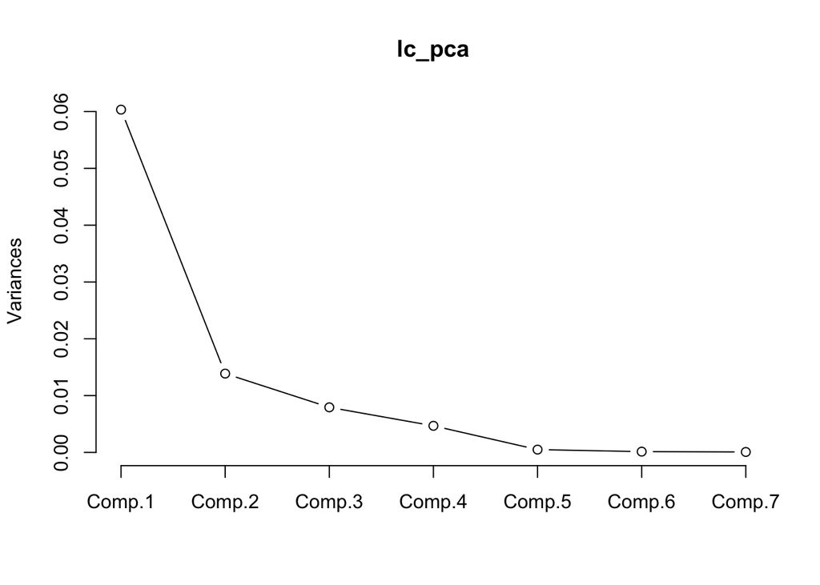

```r
#access using a scree plot
plot(lc_pca, type="lines")
```

plot the first two axes of the PCA - landcovers

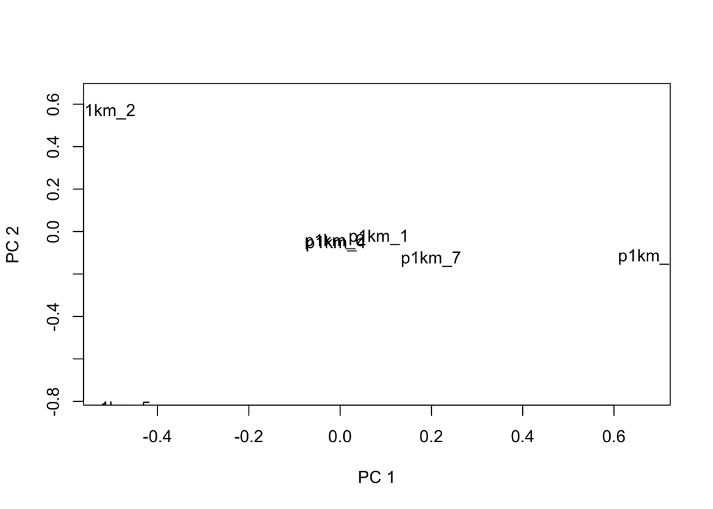

```r
plot(lc_pca$loadings,type="n",xlab="PC 1", ylab="PC 2")
text(lc_pca$loadings, labels=as.character(colnames(z_lc)), pos=1, cex=1)
```

plot the first two axes of the PCA - sites

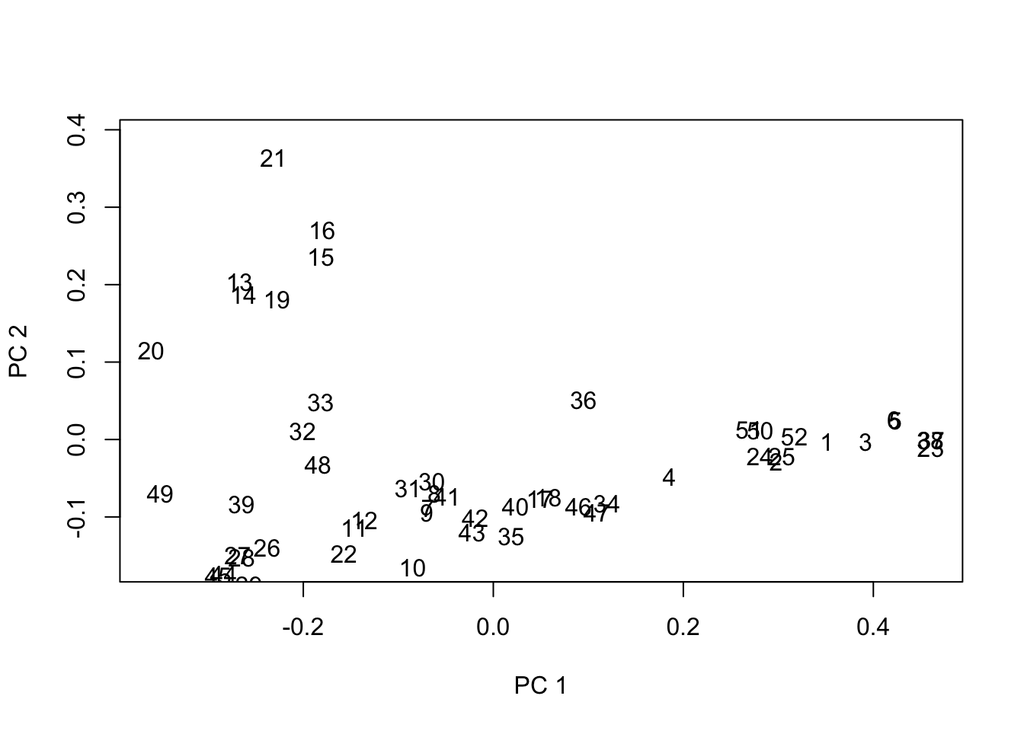

```r
plot(lc_pca$scores,type="n",xlab="PC 1", ylab="PC 2")
text(lc_pca$scores, labels=as.character(rownames(z_lc)), pos=1, cex=1)
```

biplot

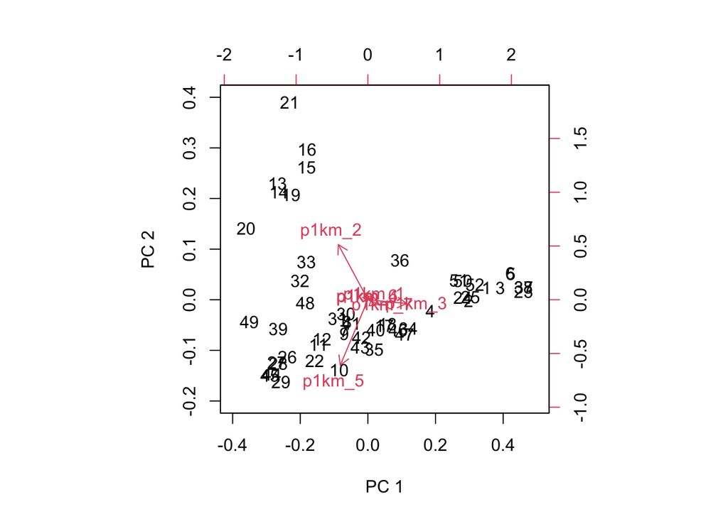

```r
biplot(lc_pca$scores,lc_pca$loading,xlab="PC 1", ylab="PC 2",ylim=c(-0.2,0.4), xlim=c(-0.4,0.5))
```

biplot - replace site numbers with ’*’

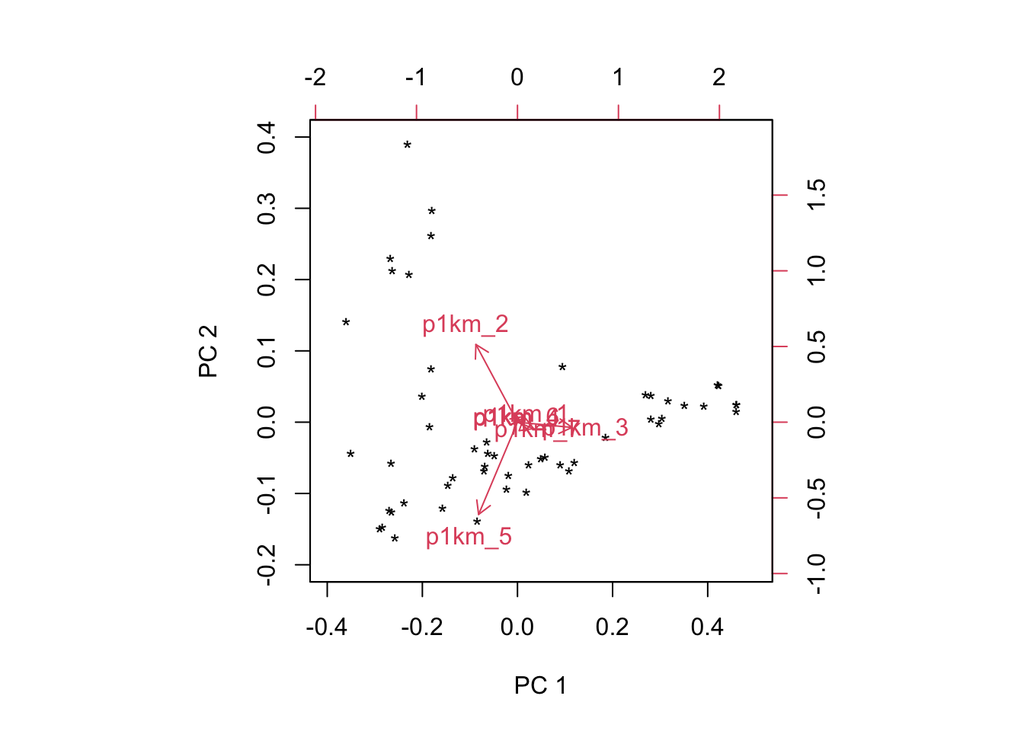

```r
biplot(lc_pca$scores,lc_pca$loading,xlabs= rep("*",52), xlab="PC 1", ylab="PC 2",ylim=c(-0.2,0.4), xlim=c(-0.4,0.5))
```

make a nicer plot using ggplot

start by reformating the pca dataframe to have information on site

```r
df_out <- as.data.frame(lc_pca$scores)
df_out$group <- lc$Field_Type
df_out$sampled <- lc$sampled

df_out <- df_out %>%
  mutate(sampled2 = recode(sampled, "N" = 0.5, "Y"=1))

df_out$sampled2 <- as.factor(df_out$sampled2)
```

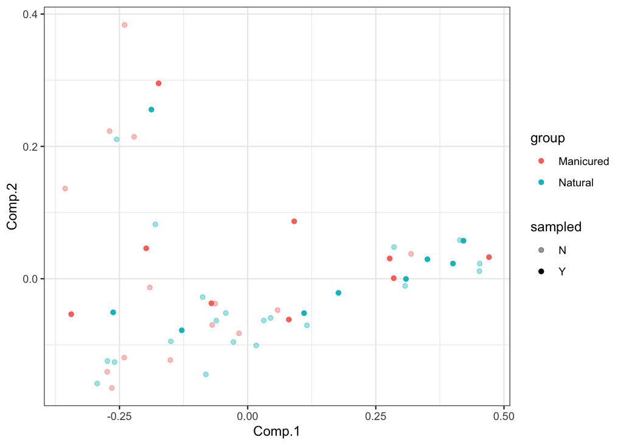

```r
ggplot(df_out, aes(x=Comp.1, y =Comp.2, color=group))+
  geom_point(aes(alpha = sampled), position = position_jitter(h=0.01,w=0.01)) +
  scale_alpha_discrete(range = c(0.4,1)) +
  theme_bw()
```

now try ggbiplot

```r
#lc.groups <- lc$Field_Type
#lc.samp <- lc$sampled

lc <- lc %>%
  unite("GS", Field_Type, sampled, remove = F)

unique(lc$GS)
```

```
## [1] "Natural_Y"   "Natural_N"   "Manicured_N" "Manicured_Y"
```

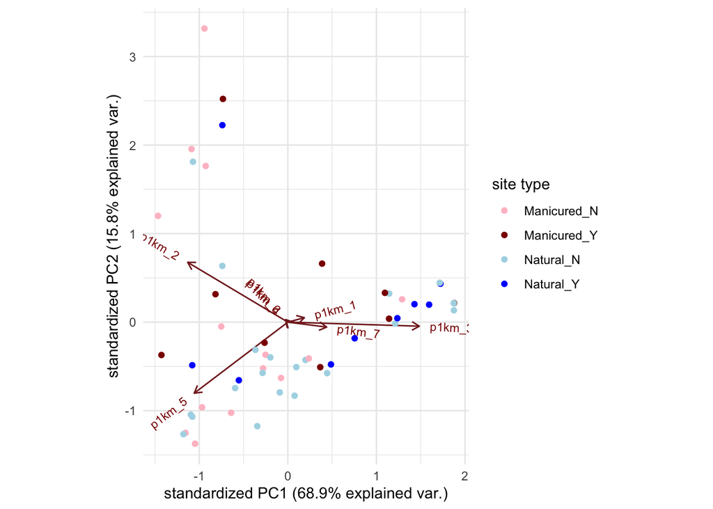

```r
lc.newgroups <- lc$GS

ggbiplot(lc_pca, groups = lc.newgroups) +
  scale_color_manual(name = "site type", values = c("pink", "darkred","lightblue", "blue")) +
  theme_minimal()
```

the issue here is that site points are overlapping…

okay so the negative values of PC1 have high proportions of developed and residential and the positive values of PC1 have high proportions of forest (and to some extent wetland)

## to do

rename PC1km_# with the actual land cover they represent  
recreate for PC1 at 500m when i figure out the best way to plot…  
make something like the last plot in section 5.4 of this website: https://bioconductor.org/packages/devel/bioc/vignettes/PCAtools/inst/doc/PCAtools.html#modify-bi-plots